# Capstone_Project

| **Telco Customer Churn** |
| --- |

## Problem Statement

Customer churn is a major problem and one of the most important concerns for large companies. Due to the direct effect on the revenues of the companies, especially in the telecom field, companies are seeking to develop means to predict potential customer to churn. Therefore, finding factors that increase customer churn is important to take necessary actions to reduce this churn. The main contribution of our work is to develop a churn prediction model which assists telecom operators to predict customers who are most likely are subjected to churn. The model developed in this work uses machine learning techniques on big data platform and builds a new way of features’ engineering and selection.

## Icon Legends

| **Inferences from Outcome** | **Additional Reads** | **Lets do it** | **Quick Tips** | **Python Libraries** |
| --- | --- | --- | --- | --- |

## Table of Content

1. **Data Set Import**
   - 1.1 - Data dictionary
   - 1.2 - Load data into a Dataframe
   - 1.3 - About data
2. **EDA**
   - 2.1 - Correcting data types
   - 2.2 - Null value treatment
   - 2.3 - Storing target, independent (numerical and categorical) variables*
3. **Visualization**
   - 3.1 - Target variable
   - 3.2 - Numerical variables
     - 3.2.1 - Numerical vs Target variable
     - 3.2.2 - Correlation in Numerical variable
   - 3.3 - Categorical variable
     - 3.3.1 - Categorical vs Target variable
     - 3.3.2 - Calculate Churn Rate in Different classes
     - 3.3.3 - Create Dummies for Categorical variable
     - 3.3.4 - Correlations in categorical variables
   - 3.4 - Creating a data frame of all independent variables
4. **Pre Processing**
   - 4.1 - Check collinearity
   - 4.2 - Spliting data set into train and test
   - 4.3 - Standardization
5. **Model Building**
   - 5.1 - LogisticRegression
     - 5.1.1 - Model
     - 5.1.2 - Parameter Tuning for Logistic Regression
     - 5.1.3 - reports and metrics on train data set
     - 5.1.3 - reports and metrics on test data set
   - 5.2 - Decision Tree
   - 5.3 - Random Forest
   - 5.4 - K Nearest Neighbors (KNN)
   - 5.5 - Naive Bayes

## 1. Data Set Import

### 1.1 Data Dictionary

The dataset contains information about several factors to Predict behavior to retain customers.  
Attribute information:

**customerID:** Uinque ID provided for every customer.

**gender:** Whether the customer is a male or a female.

**SeniorCitizen:** Whether the customer is a senior citizen or not (1, 0).

**Partner:** Whether the customer has a partner or not (Yes, No).

**Dependents:** Whether the customer has dependents or not (Yes, No).

**tenure:** Number of months the customer has stayed with the company.

**PhoneService:** Whether the customer has a phone service or not (Yes, No).

**MultipleLines:** Whether the customer has multiple lines or not (Yes, No, No phone service).

**InternetService:** Customer’s internet service provider (DSL, Fiber optic, No).

**OnlineSecurity:** Whether the customer has online security or not (Yes, No, No internet service).

**OnlineBackup:** Whether the customer has online backup or not (Yes, No, No internet service)

**DeviceProtection:** Whether the customer has device protection or not (Yes, No, No internet service)

**TechSupport:** Whether the customer has tech support or not (Yes, No, No internet service)

**StreamingTV:** Whether the customer has streaming TV or not (Yes, No, No internet service)

**StreamingMovies:** Whether the customer has streaming movies or not (Yes, No, No internet service)

**Contract:** The contract term of the customer (Month-to-month, One year, Two year)

**PaperlessBilling:** Whether the customer has paperless billing or not (Yes, No)

**PaymentMethod:** The customer’s payment method (Electronic check, Mailed check, Bank transfer (automatic), Credit card (automatic))

**MonthlyCharges:** The amount charged to the customer monthly

**TotalCharges:** The total amount charged to the customer

**Churn:** Whether the customer churned or not (Yes or No)

|  | **import libraries** |
| --- | --- |

```python
# import 'Pandas'
import pandas as pd

# import 'Numpy'
import numpy as np

# import subpackage of Matplotlib
import matplotlib.pyplot as plt
# import colours from matplotlib
from matplotlib.colors import ListedColormap

# import 'Seaborn'
import seaborn as sns

# to suppress warnings
from warnings import filterwarnings
filterwarnings('ignore')

# display all columns of the dataframe
pd.options.display.max_columns = None

# display all rows of the dataframe
pd.options.display.max_rows = None

# to display the float values upto 6 decimal places
pd.options.display.float_format = '{:.6f}'.format

# set the plot size using 'rcParams'
# once the plot size is set using 'rcParams', it sets the size of all the forthcoming plots in the file
# pass width and height in inches to 'figure.figsize'
plt.rcParams['figure.figsize'] = [10,5]

%matplotlib inline
```

### 1.2 Load data into a Dataframe

|  | **Read and display data to get insights from the data** |
| --- | --- |

```python
# importing the data of csv into variable df_churn
df_churn = pd.read_csv('WA_Fn-UseC_-Telco-Customer-Churn.csv')

# displaying 5 rows of data
df_churn.head(5)
```

### 1.3 About data

#### Check data types of variables in data frame

```python
# check data types of varaibles
df_churn.info()
```

[output not shown]

[output not shown]

```python
# Shape of the data
df_churn.shape
```

```
(7043, 21)
```

## 2. EDA

|  | **From data dictionary, the customerID variable contains unique values of each customer. It is a identification variable and we do not require for predciting the behaviour of customer churn** |
| --- | --- |

```python
# Removing customerID from data set
df_churn = df_churn.drop('customerID', axis =1)
```

```python
df_churn_copy = df_churn.copy()
```

#### 2.1 Correcting data types

[output not shown]

```python
# Replace '' andd ' ' (empty strings) with NaN values
df_churn["TotalCharges"].replace({'': np.nan, ' ':np.nan}, inplace = True)
```

```python
# convert the data type of TotalCharges to float
df_churn['TotalCharges'] = df_churn['TotalCharges'].astype(float)
```

|  | **From the data dictionary, we can say that the varible SeniorCitizen is catagorical variable. But it is defined as 'int' data type in data set. So we need to convert its data type.** |
| --- | --- |

```python
# convert the data type of SeniorCitizen to object
df_churn['SeniorCitizen'] = df_churn['SeniorCitizen'].astype(object)
```

```python
# check dtypes of variables
df_churn.info()
```

```
<class 'pandas.core.frame.DataFrame'>
RangeIndex: 7043 entries, 0 to 7042
Data columns (total 20 columns):
 #   Column            Non-Null Count  Dtype
---  ------            --------------  -----
 0   gender            7043 non-null   object
 1   SeniorCitizen     7043 non-null   object
 2   Partner           7043 non-null   object
 3   Dependents        7043 non-null   object
 4   tenure            7043 non-null   int64
 5   PhoneService      7043 non-null   object
 6   MultipleLines     7043 non-null   object
 7   InternetService   7043 non-null   object
 8   OnlineSecurity    7043 non-null   object
 9   OnlineBackup      7043 non-null   object
 10  DeviceProtection  7043 non-null   object
 11  TechSupport       7043 non-null   object
 12  StreamingTV       7043 non-null   object
 13  StreamingMovies   7043 non-null   object
 14  Contract          7043 non-null   object
 15  PaperlessBilling  7043 non-null   object
 16  PaymentMethod     7043 non-null   object
 17  MonthlyCharges    7043 non-null   float64
 18  TotalCharges      7032 non-null   float64
 19  Churn             7043 non-null   object
dtypes: float64(2), int64(1), object(17)
memory usage: 1.1+ MB
```

|  | **We have sucessfully converted SeniorCitizen to 'object' data type and TotalCharges to 'float'.** |
| --- | --- |

#### 2.2 Null value treatment

```python
#calculate number of null values and their percentage variable wise
null_values = df_churn.isnull().sum()
df_null_values = pd.DataFrame(null_values, columns = ['No. of Null values'])
df_null_values['% of null values'] = df_null_values/len(df_churn)*100

# display the null value and their percentage
df_null_values.sort_values(by = 'No. of Null values', ascending = False)
```

|  | No. of Null values | % of null values |
| --- | --- | --- |
| TotalCharges | 11 | 0.156183 |
| gender | 0 | 0.000000 |
| SeniorCitizen | 0 | 0.000000 |
| MonthlyCharges | 0 | 0.000000 |
| PaymentMethod | 0 | 0.000000 |
| PaperlessBilling | 0 | 0.000000 |
| Contract | 0 | 0.000000 |
| StreamingMovies | 0 | 0.000000 |
| StreamingTV | 0 | 0.000000 |
| TechSupport | 0 | 0.000000 |
| DeviceProtection | 0 | 0.000000 |
| OnlineBackup | 0 | 0.000000 |
| OnlineSecurity | 0 | 0.000000 |
| InternetService | 0 | 0.000000 |
| MultipleLines | 0 | 0.000000 |
| PhoneService | 0 | 0.000000 |
| tenure | 0 | 0.000000 |
| Dependents | 0 | 0.000000 |
| Partner | 0 | 0.000000 |
| Churn | 0 | 0.000000 |

|  | **The null values in TotalCharges are less than 0.2% of the data so we can remove those records from data set** |
| --- | --- |

```python
# drop Null valuess form the data set
df_churn= df_churn.dropna(subset = ['TotalCharges'])

# reset the index of dataset
df_churn.reset_index(drop = True, inplace = True)

#check info of data set
df_churn.info()
```

```
<class 'pandas.core.frame.DataFrame'>
RangeIndex: 7032 entries, 0 to 7031
Data columns (total 20 columns):
 #   Column            Non-Null Count  Dtype
---  ------            --------------  -----
 0   gender            7032 non-null   object
 1   SeniorCitizen     7032 non-null   object
 2   Partner           7032 non-null   object
 3   Dependents        7032 non-null   object
 4   tenure            7032 non-null   int64
 5   PhoneService      7032 non-null   object
 6   MultipleLines     7032 non-null   object
 7   InternetService   7032 non-null   object
 8   OnlineSecurity    7032 non-null   object
 9   OnlineBackup      7032 non-null   object
 10  DeviceProtection  7032 non-null   object
 11  TechSupport       7032 non-null   object
 12  StreamingTV       7032 non-null   object
 13  StreamingMovies   7032 non-null   object
 14  Contract          7032 non-null   object
 15  PaperlessBilling  7032 non-null   object
 16  PaymentMethod     7032 non-null   object
 17  MonthlyCharges    7032 non-null   float64
 18  TotalCharges      7032 non-null   float64
 19  Churn             7032 non-null   object
dtypes: float64(2), int64(1), object(17)
memory usage: 1.1+ MB
```

```python
#calculate number of null values after removing missing records in "TotalCharges" column
null_values = df_churn.isnull().sum()
df_null_values = pd.DataFrame(null_values, columns = ['No. of Null values'])
df_null_values['% of null values'] = df_null_values/len(df_churn)*100

# display the null value and their percentage
df_null_values.sort_values(by = 'No. of Null values', ascending = False)
```

|  | No. of Null values | % of null values |
| --- | --- | --- |
| gender | 0 | 0.000000 |
| SeniorCitizen | 0 | 0.000000 |
| TotalCharges | 0 | 0.000000 |
| MonthlyCharges | 0 | 0.000000 |
| PaymentMethod | 0 | 0.000000 |
| PaperlessBilling | 0 | 0.000000 |
| Contract | 0 | 0.000000 |
| StreamingMovies | 0 | 0.000000 |
| StreamingTV | 0 | 0.000000 |
| TechSupport | 0 | 0.000000 |
| DeviceProtection | 0 | 0.000000 |
| OnlineBackup | 0 | 0.000000 |
| OnlineSecurity | 0 | 0.000000 |
| InternetService | 0 | 0.000000 |
| MultipleLines | 0 | 0.000000 |
| PhoneService | 0 | 0.000000 |
| tenure | 0 | 0.000000 |
| Dependents | 0 | 0.000000 |
| Partner | 0 | 0.000000 |
| Churn | 0 | 0.000000 |

|  | **No null values are present in the data set now** |
| --- | --- |

### 2.3 Storing target, independent (numerical and categorical) variables

```python
# store target variable in seperate variable
y = df_churn['Churn']

# store independent variables in seperate data frames based on their types
df_numerical = df_churn.select_dtypes(include = np.number)

df_categorical = df_churn.select_dtypes(include = np.object).drop('Churn', axis =1)
```

[interactive chart not shown]

## 3. Visualization

### 3.1 Target variable

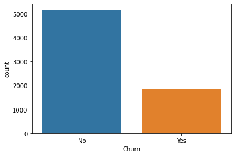

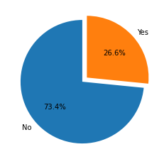

```python
size = y.value_counts()
label = y.unique()
sns.countplot(y)
plt.show()
plt.pie(size, labels = label, autopct = '%1.1f%%', startangle= 90, explode = {0, 0.1})
plt.show()
```

|  | **From the pie chart we can say that the data is not balanced. And it is Slightly Imbalanced (73:27)** |
| --- | --- |

[figure not shown]

1. When working with an imbalanced classification problem, the minority class is typically of the most interest. This means that a model’s skill in correctly predicting the class label or probability for the minority class is more important than the majority class or classes  
2. The minority class is harder to predict because there are few examples of this class, by definition. This means it is more challenging for a model to learn the characteristics of examples from this class, and to differentiate examples from this class from the majority class (or classes).

|  | **Resampling of data using SMOTE technique wil reslove imbalance issue** |
| --- | --- |

### 3.2 Numerical features

```python
# display statistical description of the numerical variables
df_numerical.describe()
```

|  | tenure | MonthlyCharges | TotalCharges |
| --- | --- | --- | --- |
| count | 7032.000000 | 7032.000000 | 7032.000000 |
| mean | 32.421786 | 64.798208 | 2283.300441 |
| std | 24.545260 | 30.085974 | 2266.771362 |
| min | 1.000000 | 18.250000 | 18.800000 |
| 25% | 9.000000 | 35.587500 | 401.450000 |
| 50% | 29.000000 | 70.350000 | 1397.475000 |
| 75% | 55.000000 | 89.862500 | 3794.737500 |
| max | 72.000000 | 118.750000 | 8684.800000 |

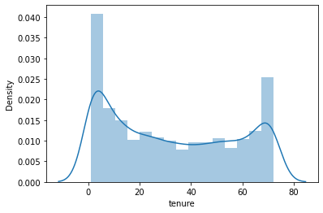

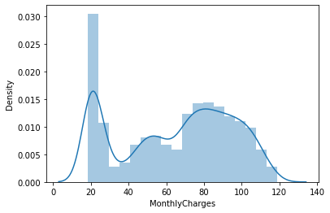

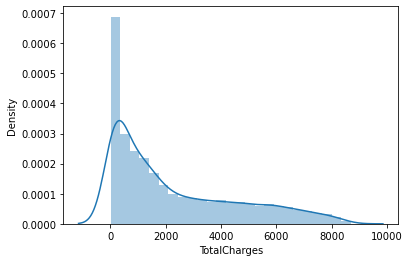

```python
# display the distribution of numerical variables
for i in df_numerical.columns:
    sns.distplot(df_numerical[i])
    plt.show()
```

```python
print('Skewness: \n', df_numerical.skew())
```

```
Skewness:
 tenure            0.237731
MonthlyCharges   -0.222103
TotalCharges      0.961642
dtype: float64
```

|  | **From the above graphs and the skewmess values we can say that Total Charges is moderately skewed** |
| --- | --- |

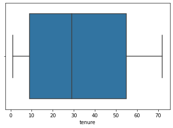

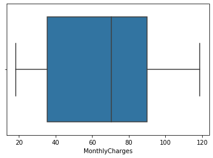

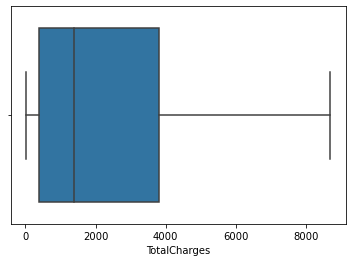

```python
# check outliers in numerical variables using boxx plots
for i in df_numerical.columns:
    sns.boxplot(df_numerical[i])
    plt.show()
```

|  | **From the above box plots we can say that there are no outliers present in data** |
| --- | --- |

#### 3.2.1 Numerical vs Target variable

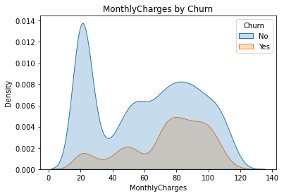

```python
# MonthlyCharges by Churn
sns.kdeplot(x = df_churn['MonthlyCharges'], hue = df_churn['Churn'], shade = True)
plt.title('MonthlyCharges by Churn')
plt.show()
```

|  | **Chrun is high when Monthly charges are high** |
| --- | --- |

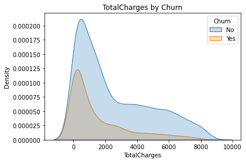

```python
#TotalCharges by Churn
sns.kdeplot(x = df_churn['TotalCharges'], hue = df_churn['Churn'], shade = True)
plt.title('TotalCharges by Churn')
plt.show()
```

[output not shown]

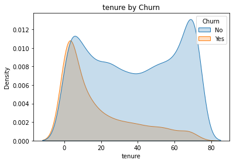

```python
#tenure by Churn
sns.kdeplot(x = df_churn['tenure'], hue = df_churn['Churn'], shade = True)
plt.title('tenure by Churn')
plt.show()
```

|  | **Churn is high when tenure is low** |
| --- | --- |

#### 3.2.2 Correlation in numerical variables

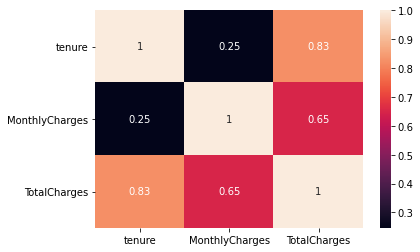

```python
# correlation between numerical variables
sns.heatmap(df_numerical.corr(), annot = True)
plt.show()
```

|  | **Tenure and TotalCharges has 83% correlation** |
| --- | --- |

### 3.3 Categorical Variables

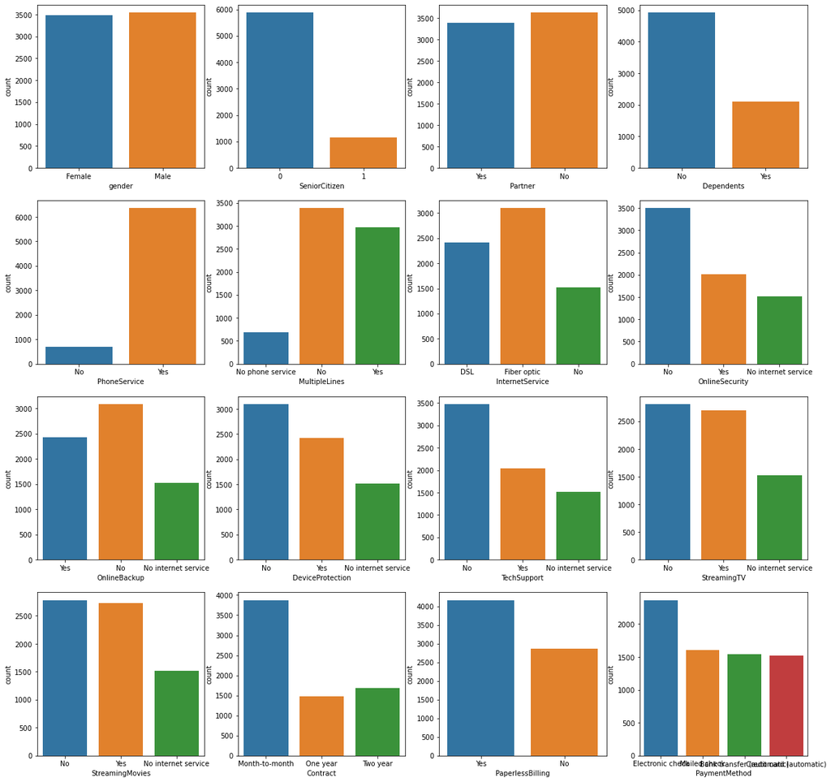

```python
ROWS , COLS = 4,4
fig, ax = plt.subplots(ROWS, COLS, figsize =(20,20))
row, col = 0,0

for i, cat in enumerate(df_categorical):
    if col == COLS - 1:
        row += 1
    col = i % COLS
    sns.countplot(x= cat, data = df_categorical, ax = ax[row, col])
```

|  | **From the above count plots we can say the below things.** |
| --- | --- |

```
There is no major difference between male and female customers in data set
Senior citizens are less in data set.
The number of customers without partner are slightly more than customers with partners
The number of customers without dependents are double the customers with dependents
The number of customers without phone services are very less when compare with customers with phone services
The number of customers with multiple phone services are slight less when compared without multiple phone services
The number of customers with fiber optic internet services is more than customers with DSL and No internet services
The number of customers with online security are less than the customer with no online security and no internet services.
The data set contains more customers without online backup than customers with online security and no inetrnet services
The data set contains more customers without device protection than customers with device protection and no inetrnet
The data set contains more customers without tech support than customers with tech support and no inetrnet
The data set contains almost same number of customers who are streaming TV and not using Tv for streaming. This number is more than customers without internet services
The data set contains almost same number of customers who are streaming movies and not streaming movies. This number is more than customers without internet services
The cutomers who opted for month-month contract are more than 1 and 2 years contracts combined.
More number of customers are opted for paperless billing in the data set considered.
More number of customers are opting for electronic check and customers opteing for mailed check, bank transfer and credit card are almost same
```

#### 3.3.1 Catagorical and Target Variable

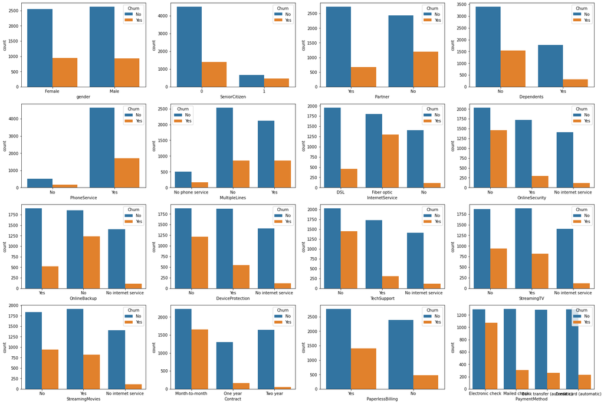

```python
# original code
ROWS, COLS = 4, 4
fig, ax = plt.subplots(ROWS, COLS, figsize=(26, 18))
row, col = 0, 0
for i, cat in enumerate(df_categorical):
    if col == COLS - 1:
        row += 1
    col = i % COLS
    sns.countplot(data=df_categorical, x=cat, hue=df_churn['Churn'], ax=ax[row, col])
```

|  | **From the Above Plots we can conclude the following points:** |
| --- | --- |

[output not shown]

#### 3.3.2 Calculate Churn Rate in Different classes

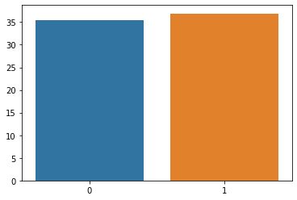

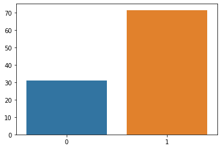

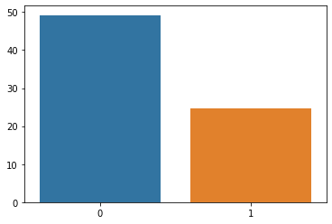

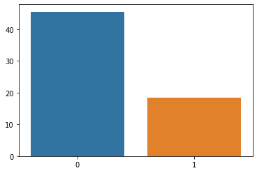

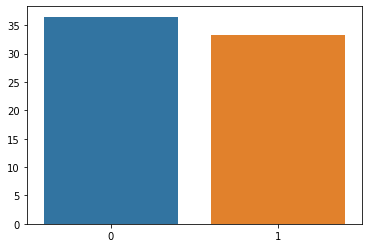

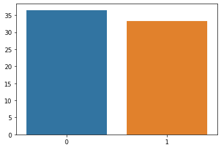

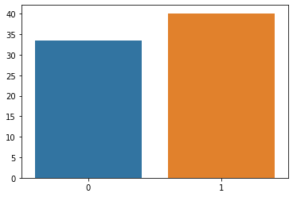

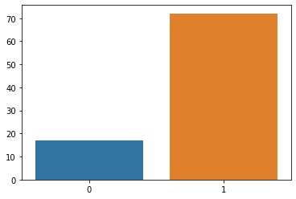

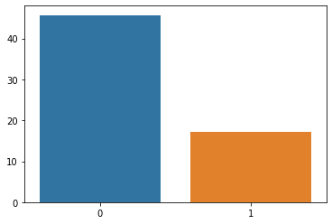

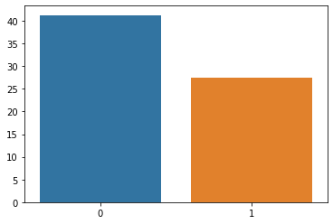

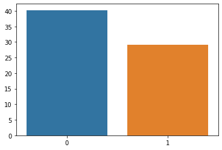

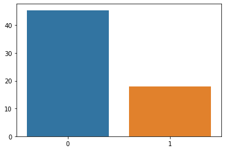

[8 more figures not shown]

```python
for i in df_categorical:
    ct = pd.crosstab(df_categorical[i], df_churn['Churn'])
    l = ct.iloc[:,1]/ct.iloc[:,0]*100
    sns.barplot(df_categorical[i].value_counts().index,l )
    plt.show()
```

|  | **Churn rate insignts:** |
| --- | --- |

```
Gender: Churn is not affected by gender.

Senior Citizen: rate of churn is higher in Senior citizens when compared to  non senior citizens

Partner: Customers with No partners are more likely to churn

Dependents: Customers with No dependent are more likely to churn

Phone Services: Most of the Customers are having phone services but the rate of churn is not dependent on it.

Multiple lines: Multiple lines is also not affecting the churn of customers

Internet Services: High churn rate is seen in subscribed customers who are using Fiber optics

Online Security, online backup, Device protection, Tech Support: Customers who are least interested in opting these services are more likely to churn.

Streaming Movies is not affecting the churn rate

Customers who opted for month-month contract are more likely to churn

Customers who are using Electronic billing are more likely to churn
```

#### 3.3.4 Create Dummies for Categorical variable

```python
# create dummies for categorical variables
df_categorical = pd.get_dummies(df_categorical, drop_first= True)

#display the categorical variables after dummification
df_categorical.head(5)
```

|  | gender_Male | SeniorCitizen_1 | Partner_Yes | Dependents_Yes | PhoneService_Yes | MultipleLines_No phone service | MultipleLines_Yes | InternetService_Fiber optic | InternetService_No | OnlineSecurity_No internet service | OnlineSecurity_Yes | OnlineBackup_No internet service | OnlineBackup_Yes | DeviceProtection_No internet service | DeviceProtection_Yes | TechSupport_No internet service | TechSupport_Yes | StreamingTV_No internet service | StreamingTV_Yes | StreamingMovies_No internet service | StreamingMovies_Yes | Contract_One year | Contract_Two year | PaperlessBilling_Yes | PaymentMethod_Credit card (automatic) | PaymentMethod_Electronic check | PaymentMethod_Mailed check |
| --- | --- | --- | --- | --- | --- | --- | --- | --- | --- | --- | --- | --- | --- | --- | --- | --- | --- | --- | --- | --- | --- | --- | --- | --- | --- | --- | --- |
| 0 | 0 | 0 | 1 | 0 | 0 | 1 | 0 | 0 | 0 | 0 | 0 | 0 | 1 | 0 | 0 | 0 | 0 | 0 | 0 | 0 | 0 | 0 | 0 | 1 | 0 | 1 | 0 |
| 1 | 1 | 0 | 0 | 0 | 1 | 0 | 0 | 0 | 0 | 0 | 1 | 0 | 0 | 0 | 1 | 0 | 0 | 0 | 0 | 0 | 0 | 1 | 0 | 0 | 0 | 0 | 1 |
| 2 | 1 | 0 | 0 | 0 | 1 | 0 | 0 | 0 | 0 | 0 | 1 | 0 | 1 | 0 | 0 | 0 | 0 | 0 | 0 | 0 | 0 | 0 | 0 | 1 | 0 | 0 | 1 |
| 3 | 1 | 0 | 0 | 0 | 0 | 1 | 0 | 0 | 0 | 0 | 1 | 0 | 0 | 0 | 1 | 0 | 1 | 0 | 0 | 0 | 0 | 1 | 0 | 0 | 0 | 0 | 0 |
| 4 | 0 | 0 | 0 | 0 | 1 | 0 | 0 | 1 | 0 | 0 | 0 | 0 | 0 | 0 | 0 | 0 | 0 | 0 | 0 | 0 | 0 | 0 | 0 | 1 | 0 | 1 | 0 |

```python
# display data types of categorical varible after dummification
df_categorical.info()
```

```
<class 'pandas.core.frame.DataFrame'>
RangeIndex: 7032 entries, 0 to 7031
Data columns (total 27 columns):
 #   Column                                 Non-Null Count  Dtype
---  ------                                 --------------  -----
 0   gender_Male                            7032 non-null   uint8
 1   SeniorCitizen_1                        7032 non-null   uint8
 2   Partner_Yes                            7032 non-null   uint8
 3   Dependents_Yes                         7032 non-null   uint8
 4   PhoneService_Yes                       7032 non-null   uint8
 5   MultipleLines_No phone service         7032 non-null   uint8
 6   MultipleLines_Yes                      7032 non-null   uint8
 7   InternetService_Fiber optic            7032 non-null   uint8
 8   InternetService_No                     7032 non-null   uint8
 9   OnlineSecurity_No internet service     7032 non-null   uint8
```

[output cut: 19 more lines]

```python
# create dummies for target variables
y = pd.get_dummies(y, drop_first= True, prefix = "Churn")

#display the target variable after dummification
y.head(5)
```

|  | Churn_Yes |
| --- | --- |
| 0 | 0 |
| 1 | 0 |
| 2 | 1 |
| 3 | 0 |
| 4 | 1 |

```python
# display data type of target varible after dummification
y.info()
```

```
<class 'pandas.core.frame.DataFrame'>
RangeIndex: 7032 entries, 0 to 7031
Data columns (total 1 columns):
 #   Column     Non-Null Count  Dtype
---  ------     --------------  -----
 0   Churn_Yes  7032 non-null   uint8
dtypes: uint8(1)
memory usage: 7.0 KB
```

#### 3.3.5 Correlations in categorical variables

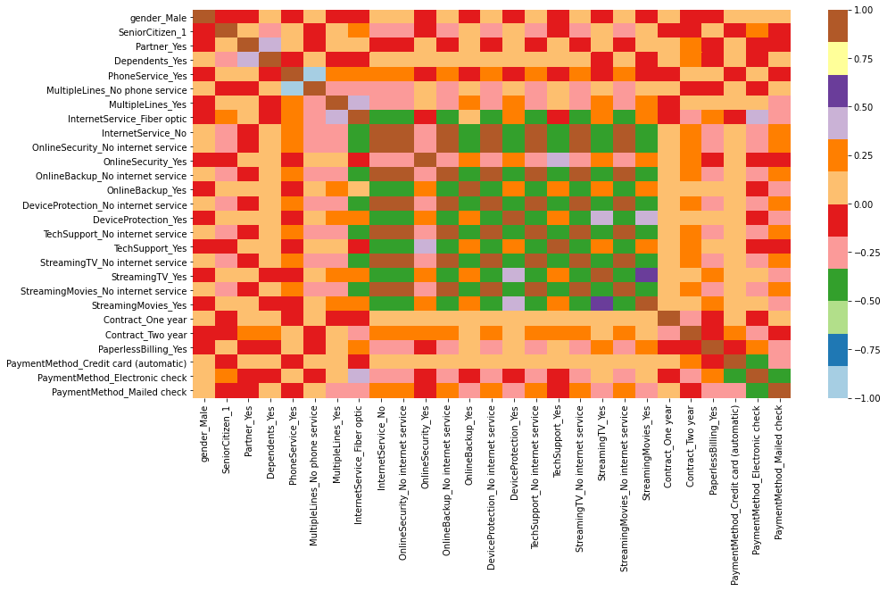

```python
plt.figure(figsize= (15,8))
# plot heatmap for categorical variables
sns.heatmap(df_categorical.corr(), cmap ="Paired")
plt.show()
```

|  | **From the above heat map we can see lot of Categorical variables have high correlation** |
| --- | --- |

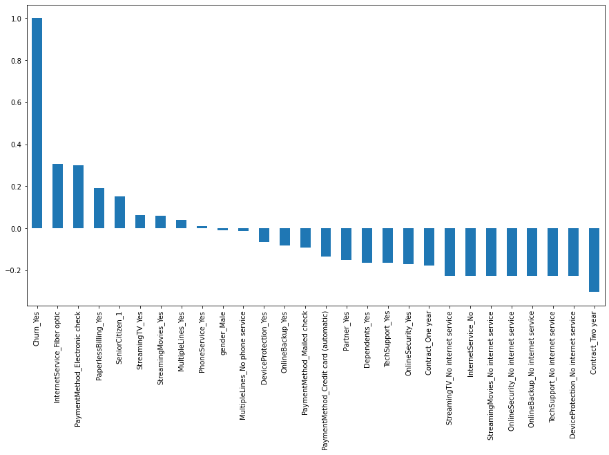

```python
plt.figure(figsize= (15,8))

# display the correlation between target variable and independent categorical variables in form of bar chart
pd.concat([df_categorical, y], axis =1).corr()['Churn_Yes'].sort_values(ascending = False).plot(kind = 'bar')
plt.show()
```

|  | **Featurs impacting Chrun** |
| --- | --- |

HIGH Churn seen in case of Month to month contracts, No online security, No Tech support, First year of subscription and Fibre Optics Internet

LOW Churn is seens in case of Long term contracts, Subscriptions without internet service and The customers engaged for 5+ years

Factors like Gender, Availability of PhoneService and no of multiple lines have alomost NO impact on Churn

### 3.4 Creating a data frame of all independent variables

```python
# combine numerical and categorical variables together
df = pd.concat([df_numerical, df_categorical], axis =1)

# display first 5 records after combining numerical and categorical variables together
df.head(5)
```

|  | tenure | MonthlyCharges | TotalCharges | gender_Male | SeniorCitizen_1 | Partner_Yes | Dependents_Yes | PhoneService_Yes | MultipleLines_No phone service | MultipleLines_Yes | InternetService_Fiber optic | InternetService_No | OnlineSecurity_No internet service | OnlineSecurity_Yes | OnlineBackup_No internet service | OnlineBackup_Yes | DeviceProtection_No internet service | DeviceProtection_Yes | TechSupport_No internet service | TechSupport_Yes | StreamingTV_No internet service | StreamingTV_Yes | StreamingMovies_No internet service | StreamingMovies_Yes | Contract_One year | Contract_Two year | PaperlessBilling_Yes | PaymentMethod_Credit card (automatic) | PaymentMethod_Electronic check | … |
| --- | --- | --- | --- | --- | --- | --- | --- | --- | --- | --- | --- | --- | --- | --- | --- | --- | --- | --- | --- | --- | --- | --- | --- | --- | --- | --- | --- | --- | --- | --- |
| 0 | 1 | 29.850000 | 29.850000 | 0 | 0 | 1 | 0 | 0 | 1 | 0 | 0 | 0 | 0 | 0 | 0 | 1 | 0 | 0 | 0 | 0 | 0 | 0 | 0 | 0 | 0 | 0 | 1 | 0 | 1 | … |
| 1 | 34 | 56.950000 | 1889.500000 | 1 | 0 | 0 | 0 | 1 | 0 | 0 | 0 | 0 | 0 | 1 | 0 | 0 | 0 | 1 | 0 | 0 | 0 | 0 | 0 | 0 | 1 | 0 | 0 | 0 | 0 | … |
| 2 | 2 | 53.850000 | 108.150000 | 1 | 0 | 0 | 0 | 1 | 0 | 0 | 0 | 0 | 0 | 1 | 0 | 1 | 0 | 0 | 0 | 0 | 0 | 0 | 0 | 0 | 0 | 0 | 1 | 0 | 0 | … |
| 3 | 45 | 42.300000 | 1840.750000 | 1 | 0 | 0 | 0 | 0 | 1 | 0 | 0 | 0 | 0 | 1 | 0 | 0 | 0 | 1 | 0 | 1 | 0 | 0 | 0 | 0 | 1 | 0 | 0 | 0 | 0 | … |
| 4 | 2 | 70.700000 | 151.650000 | 0 | 0 | 0 | 0 | 1 | 0 | 0 | 1 | 0 | 0 | 0 | 0 | 0 | 0 | 0 | 0 | 0 | 0 | 0 | 0 | 0 | 0 | 0 | 1 | 0 | 1 | … |

```python
# display data types of varible after combining numerical and categorical variables together
df.info()
```

```
<class 'pandas.core.frame.DataFrame'>
RangeIndex: 7032 entries, 0 to 7031
Data columns (total 30 columns):
 #   Column                                 Non-Null Count  Dtype
---  ------                                 --------------  -----
 0   tenure                                 7032 non-null   int64
 1   MonthlyCharges                         7032 non-null   float64
 2   TotalCharges                           7032 non-null   float64
 3   gender_Male                            7032 non-null   uint8
 4   SeniorCitizen_1                        7032 non-null   uint8
 5   Partner_Yes                            7032 non-null   uint8
 6   Dependents_Yes                         7032 non-null   uint8
 7   PhoneService_Yes                       7032 non-null   uint8
 8   MultipleLines_No phone service         7032 non-null   uint8
 9   MultipleLines_Yes                      7032 non-null   uint8
```

[output cut: 22 more lines]

## 4. Pre-Processing

### 4.1 Check collinearity

|  | Check the collinearity using correlation matrix Get the Features which needs to be dropped |
| --- | --- |

```python
# calculate correlation matrix
corr_matrix = df.corr().abs()

# create matrix with correlation matrix
upper = corr_matrix.where(np.triu(np.ones(corr_matrix.shape), k=1).astype(np.bool))

# stores the coloumns with high collinearity
to_drop = [column for column in upper.columns if any(upper[column] > 0.95)]

# Displays Columns which are dropped
to_drop
```

```
['MultipleLines_No phone service',
 'OnlineSecurity_No internet service',
 'OnlineBackup_No internet service',
 'DeviceProtection_No internet service',
 'TechSupport_No internet service',
 'StreamingTV_No internet service',
 'StreamingMovies_No internet service']
```

|  | **Drop features with high collinearity** |
| --- | --- |

```python
# Drop features with high collinearity
df.drop(to_drop, axis=1, inplace=True)
```

### 4.2 Spliting data set into train and test

|  | **import libraries** |
| --- | --- |

```python
# to split data into train and test
from sklearn.model_selection import train_test_split

import statsmodels.api as sm
```

```python
df.head()
```

|  | tenure | MonthlyCharges | TotalCharges | gender_Male | SeniorCitizen_1 | Partner_Yes | Dependents_Yes | PhoneService_Yes | MultipleLines_Yes | InternetService_Fiber optic | InternetService_No | OnlineSecurity_Yes | OnlineBackup_Yes | DeviceProtection_Yes | TechSupport_Yes | StreamingTV_Yes | StreamingMovies_Yes | Contract_One year | Contract_Two year | PaperlessBilling_Yes | PaymentMethod_Credit card (automatic) | PaymentMethod_Electronic check | PaymentMethod_Mailed check |
| --- | --- | --- | --- | --- | --- | --- | --- | --- | --- | --- | --- | --- | --- | --- | --- | --- | --- | --- | --- | --- | --- | --- | --- |
| 0 | 1 | 29.850000 | 29.850000 | 0 | 0 | 1 | 0 | 0 | 0 | 0 | 0 | 0 | 1 | 0 | 0 | 0 | 0 | 0 | 0 | 1 | 0 | 1 | 0 |
| 1 | 34 | 56.950000 | 1889.500000 | 1 | 0 | 0 | 0 | 1 | 0 | 0 | 0 | 1 | 0 | 1 | 0 | 0 | 0 | 1 | 0 | 0 | 0 | 0 | 1 |
| 2 | 2 | 53.850000 | 108.150000 | 1 | 0 | 0 | 0 | 1 | 0 | 0 | 0 | 1 | 1 | 0 | 0 | 0 | 0 | 0 | 0 | 1 | 0 | 0 | 1 |
| 3 | 45 | 42.300000 | 1840.750000 | 1 | 0 | 0 | 0 | 0 | 0 | 0 | 0 | 1 | 0 | 1 | 1 | 0 | 0 | 1 | 0 | 0 | 0 | 0 | 0 |
| 4 | 2 | 70.700000 | 151.650000 | 0 | 0 | 0 | 0 | 1 | 0 | 1 | 0 | 0 | 0 | 0 | 0 | 0 | 0 | 0 | 0 | 1 | 0 | 1 | 0 |

```python
# split data into 80 -20% and store them in train and test data sets
# set 'random_state' to generate the same dataset each time you run the code
# 'test_size' returns the proportion of data to be included in the testing set

# split data into 80 -20% and store them in train and test data sets
X_train, X_test, y_train, y_test = train_test_split(df, y, test_size=0.2, random_state=123)
```

### 4.3 Standardization

|  | **import libraries** |
| --- | --- |

```python
from sklearn.preprocessing import StandardScaler
```

```python
df.columns
```

```
Index(['tenure', 'MonthlyCharges', 'TotalCharges', 'gender_Male',
       'SeniorCitizen_1', 'Partner_Yes', 'Dependents_Yes', 'PhoneService_Yes',
       'MultipleLines_Yes', 'InternetService_Fiber optic',
       'InternetService_No', 'OnlineSecurity_Yes', 'OnlineBackup_Yes',
       'DeviceProtection_Yes', 'TechSupport_Yes', 'StreamingTV_Yes',
       'StreamingMovies_Yes', 'Contract_One year', 'Contract_Two year',
       'PaperlessBilling_Yes', 'PaymentMethod_Credit card (automatic)',
       'PaymentMethod_Electronic check', 'PaymentMethod_Mailed check'],
      dtype='object')
```

```python
# Standardizing the data with Standard Scaler
ss = StandardScaler()

X_train = ss.fit_transform(X_train)
X_test = ss.transform(X_test)
```

```python
#display standardised data in a data frame

X_train = pd.DataFrame(X_train, columns = df.columns)
X_train.shape
```

```
(5625, 23)
```

```python
y_train = y_train.reset_index(drop=True)
y_train.head()
```

|  | Churn_Yes |
| --- | --- |
| 0 | 1 |
| 1 | 0 |
| 2 | 0 |
| 3 | 1 |
| 4 | 0 |

```python
#display standardised data in a data frame

X_test = pd.DataFrame(X_test, columns = df.columns)
X_test.head()
```

|  | tenure | MonthlyCharges | TotalCharges | gender_Male | SeniorCitizen_1 | Partner_Yes | Dependents_Yes | PhoneService_Yes | MultipleLines_Yes | InternetService_Fiber optic | InternetService_No | OnlineSecurity_Yes | OnlineBackup_Yes | DeviceProtection_Yes | TechSupport_Yes | StreamingTV_Yes | StreamingMovies_Yes | Contract_One year | Contract_Two year | PaperlessBilling_Yes | PaymentMethod_Credit card (automatic) | PaymentMethod_Electronic check | PaymentMethod_Mailed check |
| --- | --- | --- | --- | --- | --- | --- | --- | --- | --- | --- | --- | --- | --- | --- | --- | --- | --- | --- | --- | --- | --- | --- | --- |
| 0 | 0.098812 | -1.497286 | -0.714306 | 0.992737 | -0.436147 | -0.964539 | -0.656455 | 0.330859 | -0.862035 | -0.887045 | 1.938784 | -0.639308 | -0.727860 | -0.741917 | -0.649255 | -0.792809 | -0.804453 | -0.513853 | 1.773464 | 0.831397 | -0.529572 | -0.709371 | 1.831315 |
| 1 | -0.594228 | 0.359689 | -0.411190 | 0.992737 | -0.436147 | -0.964539 | -0.656455 | 0.330859 | -0.862035 | 1.127339 | -0.515787 | -0.639308 | -0.727860 | -0.741917 | 1.540228 | -0.792809 | -0.804453 | -0.513853 | -0.563868 | 0.831397 | -0.529572 | -0.709371 | -0.546056 |
| 2 | 1.321824 | 1.268172 | 1.974209 | 0.992737 | 2.292804 | 1.036764 | -0.656455 | 0.330859 | 1.160045 | 1.127339 | -0.515787 | -0.639308 | 1.373891 | 1.347859 | -0.649255 | 1.261337 | 1.243080 | 1.946082 | -0.563868 | 0.831397 | -0.529572 | -0.709371 | -0.546056 |
| 3 | 0.669551 | -0.293753 | 0.208356 | -1.007316 | -0.436147 | 1.036764 | -0.656455 | -3.022439 | -0.862035 | -0.887045 | -0.515787 | -0.639308 | 1.373891 | -0.741917 | 1.540228 | 1.261337 | 1.243080 | 1.946082 | -0.563868 | 0.831397 | 1.888318 | -0.709371 | -0.546056 |
| 4 | 0.180346 | 1.146486 | 0.640328 | -1.007316 | -0.436147 | 1.036764 | -0.656455 | 0.330859 | 1.160045 | 1.127339 | -0.515787 | -0.639308 | -0.727860 | 1.347859 | -0.649255 | 1.261337 | 1.243080 | -0.513853 | -0.563868 | 0.831397 | -0.529572 | 1.409700 | -0.546056 |

```python
y_test = y_test.reset_index(drop=True)
y_test.head()
```

|  | Churn_Yes |
| --- | --- |
| 0 | 0 |
| 1 | 0 |
| 2 | 0 |
| 3 | 0 |
| 4 | 1 |

## 5. Model building

|  | **import libraries** |
| --- | --- |

```python
from sklearn import metrics
from sklearn.linear_model import LogisticRegression
from sklearn.metrics import classification_report
from sklearn.metrics import cohen_kappa_score
from sklearn.metrics import confusion_matrix
from sklearn.metrics import roc_curve
from sklearn.metrics import accuracy_score
```

### 5.1 LogisticRegression

#### 5.1.1 model

```python
# add constant into data set
Xc_train = sm.add_constant(X_train)
```

```python
Xc_test = sm.add_constant(X_test)
```

```python
# create a logistic model
log_model = sm.Logit(y_train, Xc_train).fit()

# display the summary
print(log_model.summary())
```

```
Optimization terminated successfully.
         Current function value: inf
         Iterations 8
                           Logit Regression Results
==============================================================================
Dep. Variable:              Churn_Yes   No. Observations:                 5625
Model:                          Logit   Df Residuals:                     5601
Method:                           MLE   Df Model:                           23
Date:                Wed, 30 Jun 2021   Pseudo R-squ.:                     inf
Time:                        10:07:40   Log-Likelihood:                   -inf
converged:                       True   LL-Null:                        0.0000
Covariance Type:            nonrobust   LLR p-value:                     1.000
=========================================================================================================
                                            coef    std err          z      P>|z|      [0.025      0.975]
---------------------------------------------------------------------------------------------------------
const                                    -1.7528      0.061    -28.891      0.000      -1.872      -1.634
tenure                                   -1.3939      0.170     -8.201      0.000      -1.727      -1.061
MonthlyCharges                           -1.9546      1.063     -1.839      0.066      -4.038       0.129
TotalCharges                              0.6791      0.179      3.796      0.000       0.329       1.030
gender_Male                              -0.0069      0.036     -0.190      0.849      -0.078       0.064
SeniorCitizen_1                           0.0748      0.035      2.141      0.032       0.006       0.143
Partner_Yes                              -0.0127      0.043     -0.291      0.771      -0.098       0.072
Dependents_Yes                           -0.0567      0.046     -1.234      0.217      -0.147       0.033
PhoneService_Yes                          0.2204      0.216      1.021      0.307      -0.203       0.644
MultipleLines_Yes                         0.2878      0.098      2.945      0.003       0.096       0.479
InternetService_Fiber optic               1.1514      0.442      2.604      0.009       0.285       2.018
InternetService_No                       -1.0351      0.368     -2.815      0.005      -1.756      -0.314
OnlineSecurity_Yes                       -0.0430      0.090     -0.476      0.634      -0.220       0.134
OnlineBackup_Yes                          0.0605      0.093      0.652      0.514      -0.121       0.242
DeviceProtection_Yes                      0.1556      0.094      1.656      0.098      -0.029       0.340
TechSupport_Yes                           0.0074      0.092      0.081      0.935      -0.173       0.188
StreamingTV_Yes                           0.4176      0.177      2.356      0.018       0.070       0.765
StreamingMovies_Yes                       0.4050      0.178      2.275      0.023       0.056       0.754
Contract_One year                        -0.2891      0.050     -5.822      0.000      -0.386      -0.192
Contract_Two year                        -0.5579      0.083     -6.725      0.000      -0.721      -0.395
PaperlessBilling_Yes                      0.1564      0.041      3.811      0.000       0.076       0.237
PaymentMethod_Credit card (automatic)    -0.0474      0.053     -0.889      0.374      -0.152       0.057
PaymentMethod_Electronic check            0.1598      0.050      3.183      0.001       0.061       0.258
PaymentMethod_Mailed check                0.0167      0.054      0.310      0.757      -0.089       0.123
=========================================================================================================
```

#### 5.1.2 Parameter Tuning for Logistic Regression

```python
# create an empty dataframe to store the scores for various algorithms
score_card = pd.DataFrame(columns=['Probability Cutoff', 'AUC Score', 'Precision Score', 'Recall Score',
                                       'Accuracy Score', 'Kappa Score', 'f1-score'])

# append the result table for all performance scores
# performance measures considered for model comparision are 'AUC Score', 'Precision Score', 'Recall Score','Accuracy Score',
# 'Kappa Score', and 'f1-score'
# compile the required information in a user defined function
def update_score_card(model, cutoff):

    # let 'y_pred_prob' be the predicted values of y
    y_pred_prob = log_model.predict(Xc_test)

    # convert probabilities to 0 and 1 using 'if_else'
    y_pred = [ 0 if x < cutoff else 1 for x in y_pred_prob]

    # assign 'score_card' as global variable
    global score_card

    # append the results to the dataframe 'score_card'
    # 'ignore_index = True' do not consider the index labels
    score_card = score_card.append({'Probability Cutoff': cutoff,
                                    'AUC Score' : metrics.roc_auc_score(y_test, y_pred),
                                    'Precision Score': metrics.precision_score(y_test, y_pred),
                                    'Recall Score': metrics.recall_score(y_test, y_pred),
                                    'Accuracy Score': metrics.accuracy_score(y_test, y_pred),
                                    'Kappa Score':metrics.cohen_kappa_score(y_test, y_pred),
                                    'f1-score': metrics.f1_score(y_test, y_pred)},
                                    ignore_index = True)
```

```python
# consider a list of values for cut-off
cutoff = [0.1, 0.2, 0.3, 0.4, 0.5, 0.6, 0.7, 0.8, 0.9]

# use the for loop to compute performance measures for each value of the cut-off
# call the update_score_card() to update the score card for each cut-off
# pass the model and cut-off value to the function
for value in cutoff:
    update_score_card(log_model, value)
```

```python
# print the score card
print('Score Card for Logistic regression:')

# sort the dataframe based on the probability cut-off values ascending order
# 'reset_index' resets the index of the dataframe
# 'drop = True' drops the previous index
score_card = score_card.sort_values('Probability Cutoff').reset_index(drop = True)

# color the cell in the columns 'AUC Score', 'Accuracy Score', 'Kappa Score', 'f1-score' having maximum values
# 'style.highlight_max' assigns color to the maximum value
# pass specified color to the parameter, 'color'
# pass the data to limit the color assignment to the parameter, 'subset'
score_card.style.highlight_max(color = 'lightblue', subset = ['AUC Score', 'Accuracy Score', 'Kappa Score', 'f1-score'])
```

```
Score Card for Logistic regression:
```

|  | Probability Cutoff | AUC Score | Precision Score | Recall Score | Accuracy Score | Kappa Score | f1-score |
| --- | --- | --- | --- | --- | --- | --- | --- |
| 0 | 0.100000 | 0.729898 | 0.443439 | 0.953771 | 0.636816 | 0.343650 | 0.605405 |
| 1 | 0.200000 | 0.769010 | 0.523669 | 0.861314 | 0.730633 | 0.452364 | 0.651334 |
| 2 | 0.300000 | 0.772557 | 0.590226 | 0.763990 | 0.776119 | 0.501735 | 0.665960 |
| 3 | 0.400000 | 0.755676 | 0.650602 | 0.656934 | 0.796731 | 0.509895 | 0.653753 |
| 4 | 0.500000 | 0.730916 | 0.740000 | 0.540146 | 0.810235 | 0.501618 | 0.624473 |
| 5 | 0.600000 | 0.672559 | 0.784314 | 0.389294 | 0.790334 | 0.405025 | 0.520325 |
| 6 | 0.700000 | 0.574191 | 0.800000 | 0.165450 | 0.744136 | 0.193442 | 0.274194 |
| 7 | 0.800000 | 0.506797 | 0.857143 | 0.014599 | 0.711443 | 0.019111 | 0.028708 |
| 8 | 0.900000 | 0.500000 | 0.000000 | 0.000000 | 0.707889 | 0.000000 | 0.000000 |

#### 5.1.3 reports and metrics for logistic model on train data

```python
# calculate the probability for train data set using model created
y_train_pred_prob = log_model.predict(Xc_train)

# predict the test values
y_train_pred = [0 if x < 0.5 else 1 for x in y_train_pred_prob]

# display the classification report
print(classification_report(y_train,y_train_pred))
```

```
              precision    recall  f1-score   support

           0       0.85      0.90      0.87      4167
           1       0.65      0.54      0.59      1458

    accuracy                           0.81      5625
   macro avg       0.75      0.72      0.73      5625
weighted avg       0.80      0.81      0.80      5625
```

Model created is working with **81% accuray** on train data

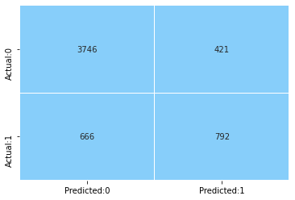

```python
# create Confusion matrix for train data
cm = confusion_matrix(y_train,y_train_pred)

#plot the confussion matrix for train data
con_matrix = pd.DataFrame(cm,columns=['Predicted:0','Predicted:1'],index=['Actual:0','Actual:1'])
sns.heatmap(con_matrix,annot=True,fmt='d',cmap=ListedColormap(['Lightskyblue']),cbar=False,linewidths=0.1)
plt.show()
```

from confussion matrix we got to know that there are 1087(666 +421), which is a big number. we need to reduce this

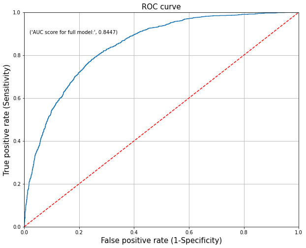

```python
plt.figure(figsize=(10,8))
fpr, tpr, thresholds = roc_curve(y_train,y_train_pred_prob)
plt.plot(fpr,tpr)

plt.xlim([0.0,1.0])
plt.ylim([0.0,1.0])

plt.plot([0,1],[0,1],'r--')

plt.title('ROC curve', fontsize = 15)
plt.xlabel('False positive rate (1-Specificity)', fontsize = 15)
plt.ylabel('True positive rate (Sensitivity)', fontsize = 15)

plt.text(x=0.02,y=0.9,s=('AUC score for full model:',round(metrics.roc_auc_score(y_train,y_train_pred_prob),4)))


plt.grid(True)
```

```python
# create a dataframe to store the values for false positive rate, true positive rate and threshold
youdens_table = pd.DataFrame({'TPR': tpr,
                             'FPR': fpr,
                             'Threshold': thresholds})

# calculate the difference between TPR and FPR for each threshold and store the values in a new column 'Difference'
youdens_table['Difference'] = youdens_table.TPR - youdens_table.FPR

# sort the dataframe based on the values of difference
# 'ascending = False' sorts the data in descending order
# 'reset_index' resets the index of the dataframe
# 'drop = True' drops the previous index
youdens_table = youdens_table.sort_values('Difference', ascending = False).reset_index(drop = True)

# print the first five observations
youdens_table.head()
```

|  | TPR | FPR | Threshold | Difference |
| --- | --- | --- | --- | --- |
| 0 | 0.780521 | 0.245980 | 0.287544 | 0.534541 |
| 1 | 0.779835 | 0.245740 | 0.287905 | 0.534095 |
| 2 | 0.779835 | 0.245980 | 0.287748 | 0.533855 |
| 3 | 0.781207 | 0.247660 | 0.285947 | 0.533547 |
| 4 | 0.792181 | 0.258699 | 0.274575 | 0.533482 |

From the above plot, we can see that our model (logistic_model) is away from the red dotted line; with the AUC score 0.8447 on train data.